# Time Series Analysis on US Monthly Unemployment Rate

Caitlyn Vasquez (cnv988@ucsb.edu)

2024-06-13

# Abstract

Although the unemployment rate in the United States has remained relatively stable over the years, there are many recent advancements that have the potential to adversely affect it such as layoff spillover, AI, and market re-correction. This report seeks to conduct a time series analysis on monthly unemployment rates in the United States and build a SARIMA model to make further predictions. We will go about this using the Box-Jenkins approach: plotting the time series data, transforming, identifying dependence orders, estimating parameters, diagnostics, and selecting an appropriate model. In order to strengthen the model and identify trends, we will utilize unit root testing and spectral analysis. This analysis includes time series plots, ACF/PACF plots, ADF tests, STLs, Shapiro-Wilk tests, periodograms, and forecasting. At the end of this report, we will explore and compare four eligible SARIMA models to determine the best-performing one and utilize it to make a next-year prediction.

# 1. Introducion

In this project, we will conducting a time series analysis on the US monthly unemployment rate. The purpose is to identify any patterns or trends in the US unemployment rate, develop a better understanding of our country’s labor market, and develop an accurate model to forecast future unemployment rates. I am building a SARIMA model according to the Box-Jenkins approach and applying methods such as unit root testing and spectral analysis to enhance my model. Skimming the data, I noticed that the highest unemployment rate is 10.8% which is a shocking discovery that prompts us to ponder the underlying reasons for this high rate. In the past, a lot of exploratory data analysis has been conducted on this data set.

I chose to analyze this particular dataset because unemployment is an issue that deeply resonates with me. Many people I know, despite being highly qualified, struggle to find jobs that align with their passions in an increasingly competitive and unforgiving job market. This dataset is important because the unemployment rate is the most commonly used indicator for understanding conditions in the labor market and its impact on the rest of society. Thus, analyzing this dataset can provide a comprehensive understanding of the economy’s health and dynamics. It can aid policymakers in crafting informed economic strategies and social programs. Businesses leverage these insights for strategic planning and workforce management, while investors use employment data to make informed decisions that impact financial markets. Additionally, time series analysis of this dataset can uncover patterns and cycles in the labor market, highlighting seasonal variations and structural economic shifts, such as technological advancements. Beyond economic implications, employment rates contribute to overall social well-being. I hope that this analysis contributes to a better understanding of employment trends, helps address challenges faced by job seekers, and provides accurate forecasts to foster a robust, informed economy and enhance societal welfare.

# 2. Data

The data was taken from the Kaggle dataset, “[US Monthly Unemployment Rate](https://www.kaggle.com/datasets/tunguz/us-monthly-unemployment-rate-1948-present/data)” [https://www.kaggle.com/datasets/tunguz/us-monthly-unemployment-rate-1948-present/data] by user Bojan Tunguz. The data was collected by the US Bureau of Labor Statistics and was collected through the Current Population Survey. It contains monthly unemployment rates ranging between January 1948 and December 2019. The values represent the proportion of unemployed persons in the labor force (%) and are non-negative. The sample size is 864.

As mentioned in the introduction, I chose this data set because of its personal resonance. This dataset is important—and useful to study—because it allows us to analyze trends, compute future predictions, and contribute to a well-informed society.

# 3. Methodology

## 3.1 SARIMA

We will be applying the Box-Jenkins method which uses the AutoRegressive Integrated Moving Average (ARIMA) models to determine the best fit of a time-series model to past values of a time series. However, we will be modifying this slightly to use the SARIMA model instead, where the “S” stands for “Seasonal.” ARIMA and SARIMA are both algorithms for forecast, taking into account past values (autoregressive, moving average) and predicts future values based on that. However, SARIMA takes into account any seasonality patterns and introduces seasonality as a parameter, thus extending its capabilities and potentially increasing accuracy. There are six steps to fitting models to time series data according to the Box-Jenkins method. These steps involve:

### Step 1: Plotting the data

As with any data analysis, we should begin by constructing a time plot of the data and inspect the graph for any anomalies.

### Step 2: Transforming

If we notice any anomalies upon inspection, applying a transformation of the data may prove useful. For example, if the variability in the data increases with time, then it will be necessary to transform the data to stabilize the variance and improve the normal approximation. In such cases, root, log, or Box-Cox power transforms can be employed.

### Step 3: Identifying dependence orders

After appropriately transforming the data, we should identify the preliminary values: $p$ (autoregressive order), $d$ (order of differencing), and $q$ (moving average order). Usually, a time plot of the data will indicate if any differencing is required. If it is, then we will difference the data once, $d=1$, and inspect the time plot of $\triangledown x_t$. If further differencing is necessary, then we can difference the data again, $d=2$, and inspect the time plot of $\triangledown^2 x_t$. However, we must be careful not to overdifference the data otherwise dependence might be introduced where none exists. In addition to time plots, assessing the ACF can also indicate whether or not differencing is necessary.

### Step 4: Estimating parameters

We must find apporpriate parameters for the SARIMA model: SARIMA$(p,d,q) \times (P,D,Q)_{S}$. We can estimate the parameters by analyzing the sample ACF and PACF plots. If we transform or difference the time series (which we do), we examine those ACF/PACF plots to determine the parameters of the non-seasonal and seasonal components of the SARIMA model.

### Step 5: Diagnostics

A complete diagnosis includes:

- plotting the time series of the standard residuals,
- plotting the estimated ACF of the standardized residuals,
- plotting the normal Q-Q plot of the standardized residuals, and finally
- plotting the p values for the Ljung-Box statistic and determining whether the Q-statistic is significant or not

### Step 6: Model selection

Finally, to select the best performing model, we compare the AIC, AICc, and the BIC across all models. Lower values are ideal.

## 3.2: Unit Root Testing

Unit root tests determines whether a time series is non-stationary and possesses a unit root. After defining a test statistic or significance level, we can either accept or reject the null hypothesis. The null hypothesis is that the a unit root exists and the alternative hypothesis implies stationarity, trend stationarity, or explosive root depending on the test that is applied.

In this case, we will be applying the Augmented Dickey-Fuller (ADF) test. The null hypothesis is that the data are non-stationary and the alternative hypothesis is that the data are stationary. We set the significance level = 0.01 to provide higher confidence in concluding stationarity. If the p-value is less than or equal to the significance level, we reject the null hypothesis. If the p-value is greater than the significance level, we fail to reject the null hypothesis. We can also define a critical value according to the Dickey-Fuller $t$-distribution to test our hypothesis. The ADF statistic is a negative number where the more negative it is, the stronger the rejection of the hypothesis that there is a unit root at some level of confidence.

## 3.3: Spectral Analysis

Spectral analysis is a powerful technique used in time series analysis to examine the underlying structure of the data by analyzing its frequency components. We can identify periodic patterns or repeated cycles, particularly through the `mvspec` function. It is used to estimate the spectral density using kernel smoothing. We will use the Daniell Kernel as our pre-defined `kernel` parameter, a simple moving average kernel. The kernel smoothing helps in reducing the variance of the periodogram estimates, making the spectral density estimates more reliable.

# 4. Results

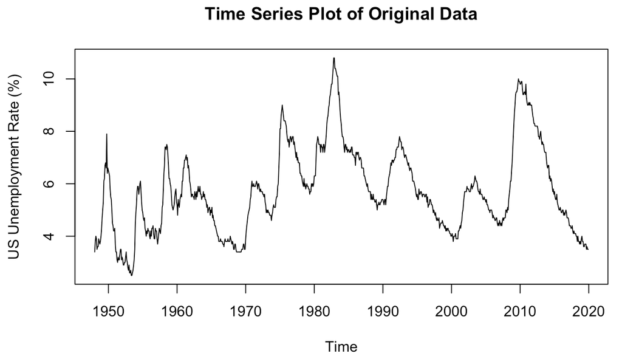

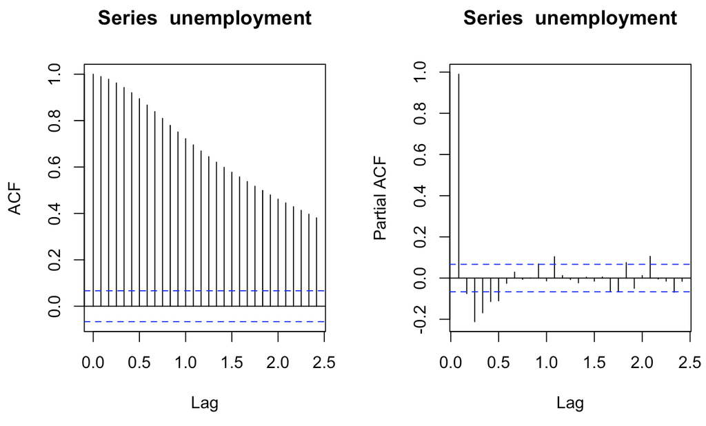

**Figure 1:** Time Series Plot of Original Data

**Figure 2:** ACF and PACF of Original Data

To double check our assumption that there is a seasonal component, we will perform a Seasonal decomposition of Time series by Less (STL) which breaks up the time series into seasonal, trend, and irregular components.

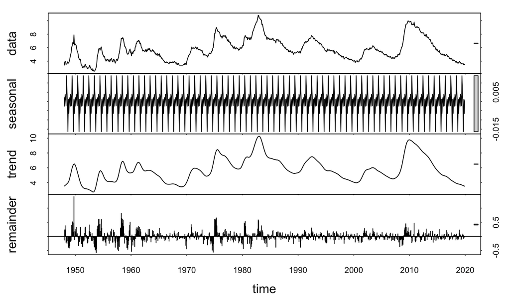

**Figure 3:** Decomposition of Original Data

Since we have identified that the data is not normal, we want to transform the data to stabilize the variance and improve the normal approximation. The slowly decaying ACF and PACF $\phi_{1,1} \approx 1$ of the original data [Figure 2] also suggests us to take the log. In this analysis, we will be applying a log transformation since our data is strictly positive.

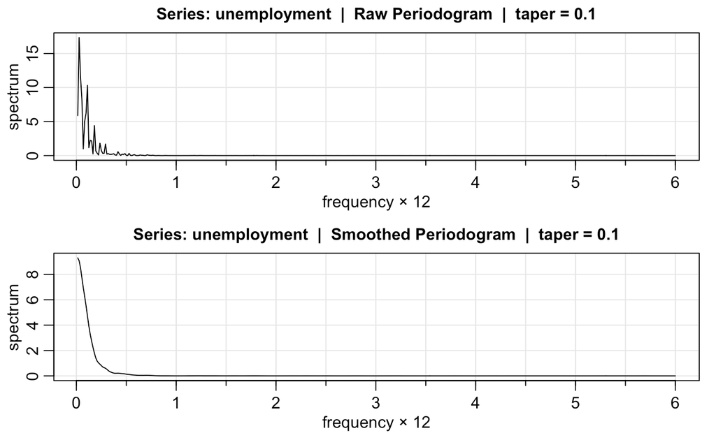

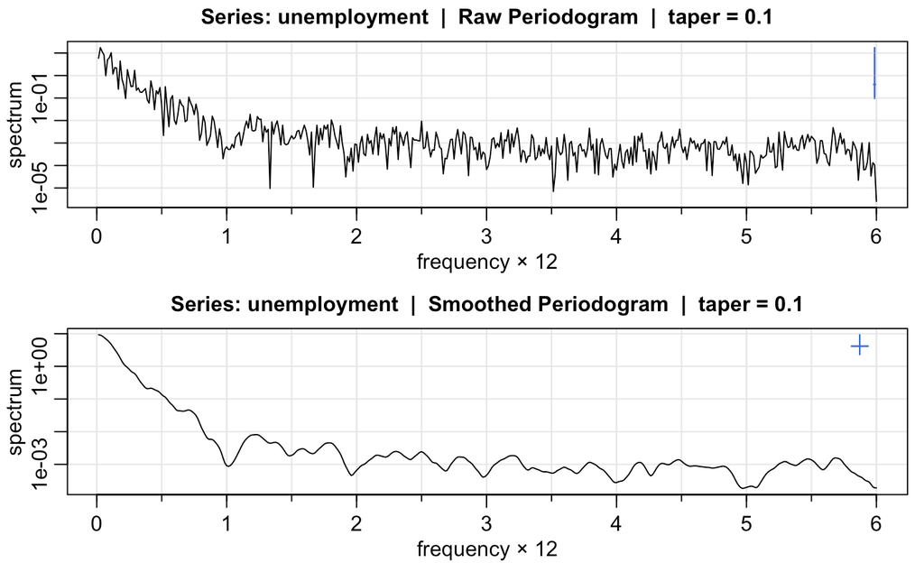

**Figure 4:** Periodogram of Original Data

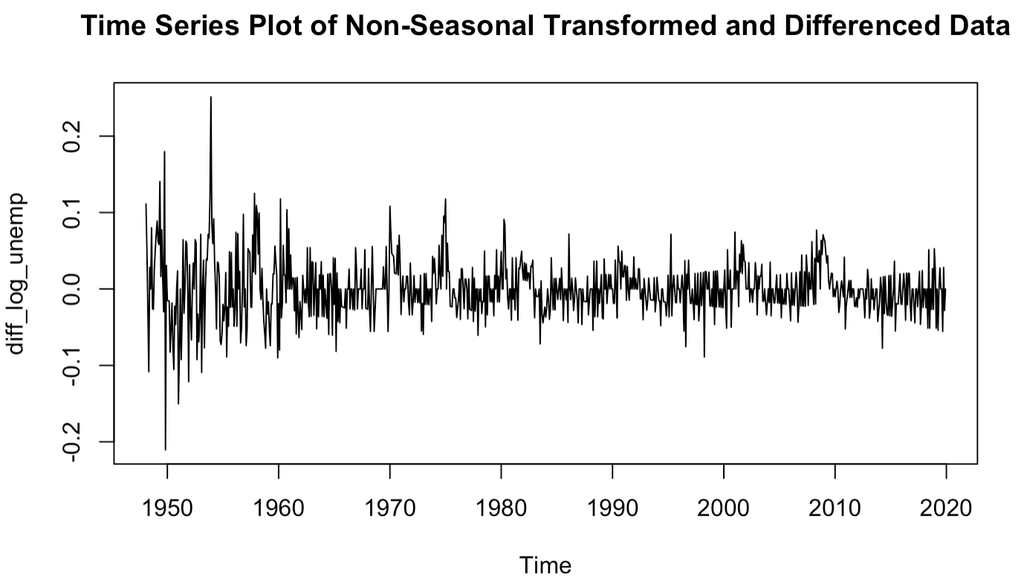

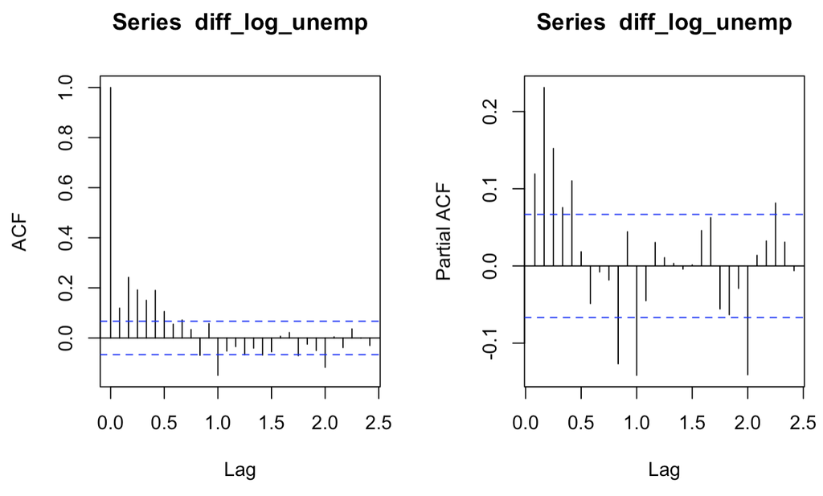

**Figure 6:** Time Series Plot of Non-Seasonal Transformed and Differenced Data

**Figure 7:** ACF and PACF of Non-Seasonal Transformed and Differenced Data

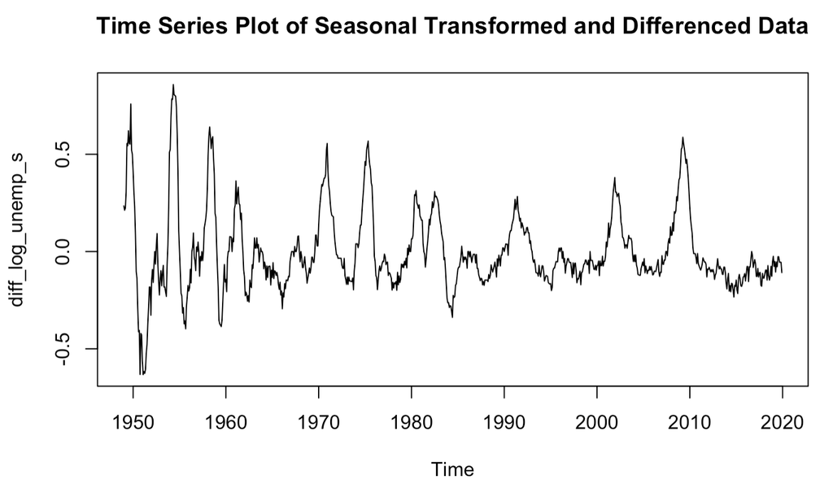

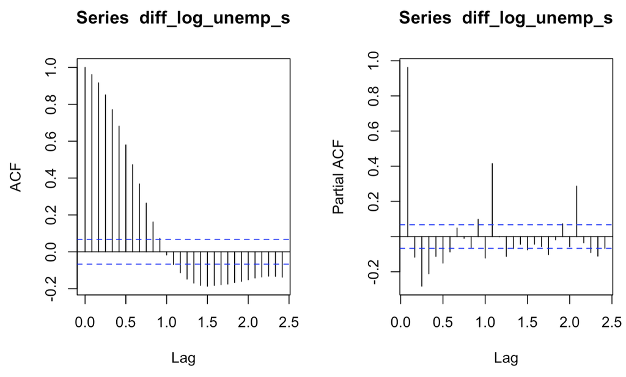

**Figure 8:** Time Series Plot of Seasonal Transformed and Differenced Data

**Figure 9:** ACF and PACF of Seasonal Transformed and Differenced Data

We need to find the values $p$, $d$, $q$, $P$, $D$, $Q$, and $S$ for our SARIMA model. First, we will work with the non-seasonal parameters of the SARIMA model, namely, $p$, $d$, and $q$. We have established that $d=1$. To determine $p$ and $q$, we will refer to the ACF/PACF plots [Figure 7] of our differenced and transformed data. In both plots, it’s not clear whether they are tailing off or cutting off, which is where ARMA comes in. We will test out a few p and q combinations. To get a $p$ value for AR for ARMA model, we will look at the PACF plots for spikes. The most prominent spikes are at 2 and 3. Thus it’s AR(2) and AR(3). To get a $q$ value, we will look at the ACF plot. The most prominent spike is at a value of 2. Thus it’s MA(2). So for the non-seasonal parameters, we will try (2,1,2) and (3,1,2).

Now let’s identify the seasonal parameters. The data is on a monthly level so $S=12$. There is an indication that seasonality exists, mostly by looking at the decomposed stacked plots [Figure 3] with data, seasonality, trend, and difference. Since the series has a stable seasonal pattern over time, $D=1$. Looking at the ACF/PACF plots [Figure 9] for the seasonally differenced data, we see that the ACF tails off and the PACF cuts off after 1, indicating AR(1). So we will set the seasonal parameters (1, 1, 0). However, we will also try (0, 0, 0) assuming no seasonality as well.

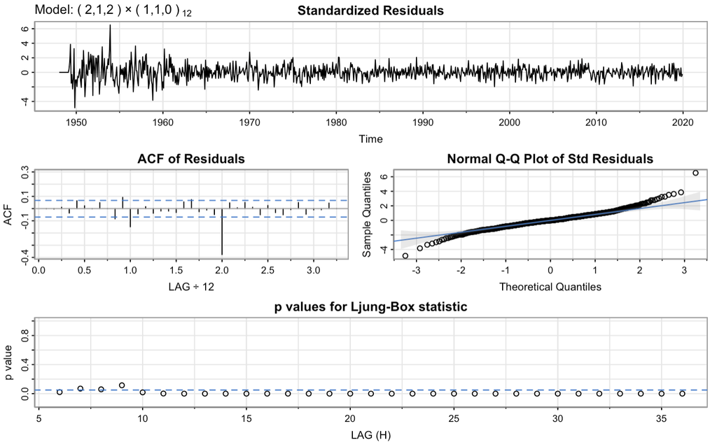

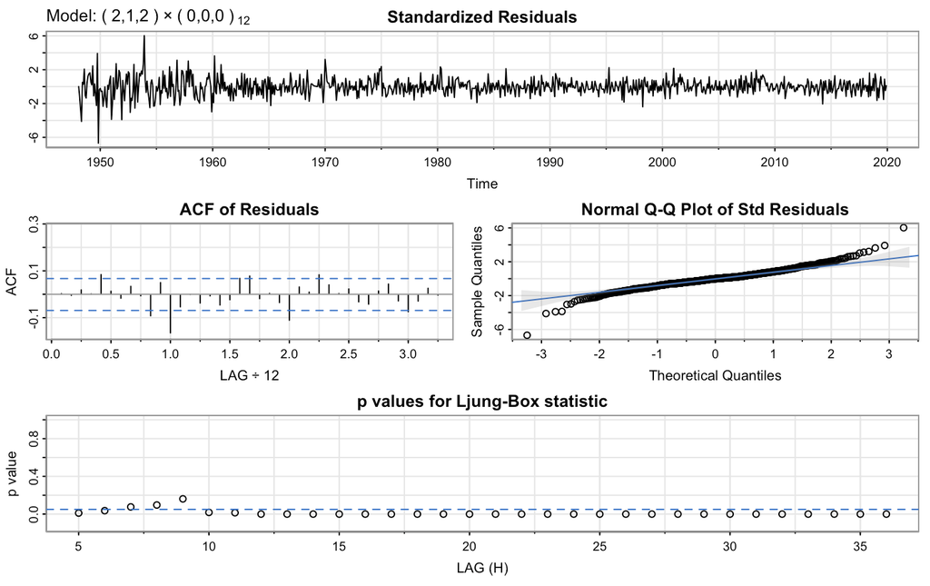

**Figure 10:** Model 1 Diagnostics

**Figure 11:** Model 2 Diagnostics

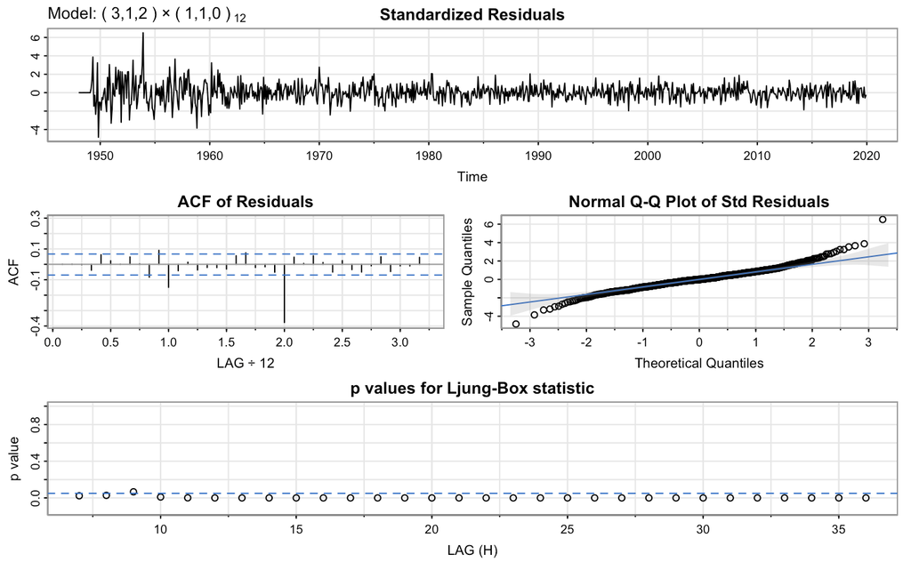

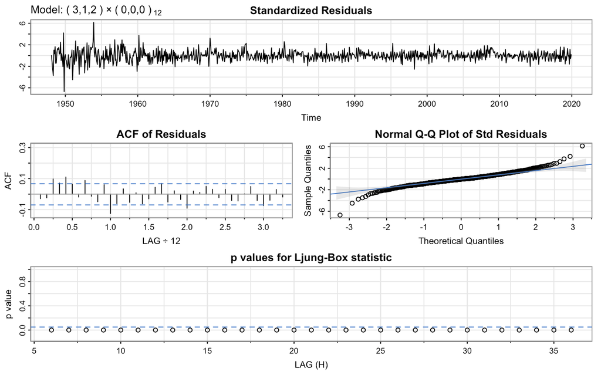

**Figure 12:** Model 3 Diagnostics

**Figure 13:** Model 4 Diagnostics

For the SARIMA$(2,1,2) \times (1,1,0)_{12}$ model [Figure 10], there is no obvious patterns in the standard residuals plot but there are some outliers exceeding 2 standard deviations in magnitude. The plot of the estimated ACF of the residuals shows no apparent departure from model assumptions except a significant lag value of 2. The normal Q-Q plot of the residuals show that the assumption of normality is reasonable, although there are some outliers. Many of the Q-statistics are statistically significant. The AIC, AICc, and BIC values are -3.271947, -3.271863, and -3.238451, respectively.

For the SARIMA$(2,1,2) \times (0,0,0)_{12}$ model [Figure 11], there is no obvious patterns in the standard residuals plot but there are some outliers exceeding 2 standard deviations in magnitude. The plot of the estimated ACF of the residuals shows no apparent departure from model assumptions except a significant lag value of 1. The normal Q-Q plot of the residuals show that the assumption of normality is reasonable, although there are some outliers. Many of the Q-statistics are statistically significant, but not as many compared to the other models. The AIC, AICc, and BIC values are -3.790915, -3.790834, and -3.757788, respectively.

For the SARIMA$(3,1,2) \times (1,1,0)_{12}$ model [Figure 12], there is no obvious patterns in the standard residuals plot but there are some outliers exceeding 2 standard deviations in magnitude. The plot of the estimated ACF of the residuals shows no apparent departure from model assumptions except a significant lag value of 2. The normal Q-Q plot of the residuals show that the assumption of normality is reasonable, although there are some outliers. Many of the Q-statistics are statistically significant. The AIC, AICc, and BIC values are -3.269863, -3.269745, and -3.230784, respectively.

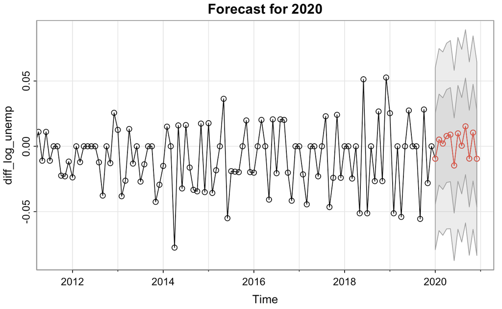

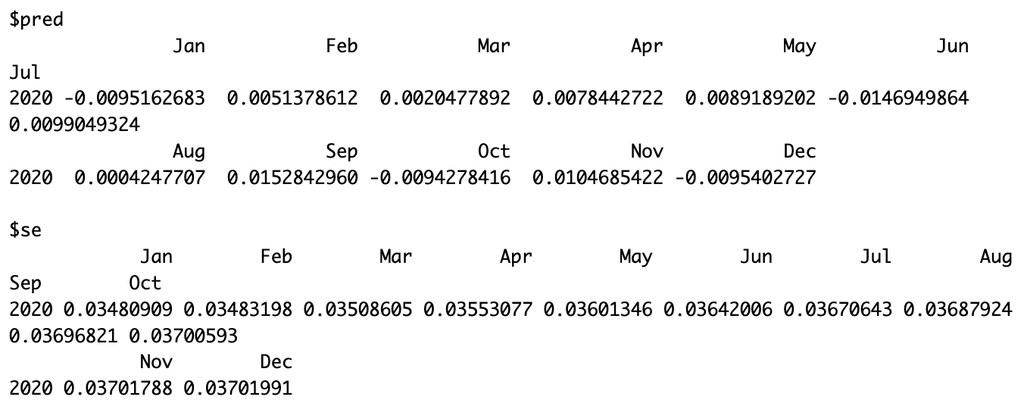

**Figure 14:** Next Year Forecast

**Figure 15:** Forecast Values

# Conclusion and Future Study

We used the log and differenced ACF and PACF to determine our non-seasonal parameters for the SARIMA model, where we identified AR(2), AR(3), and MA(2) and chose to test (2, 1, 2) and (3, 1, 2). We then used the decomposed plot and seasonal log and differenced ACF and PACF plots to determine our seasonal parameters, where we identified AR(1) and chose to test (1, 1, 0) and (0, 0, 0) to see how our model would perform assuming no seasonality.

If given more time, I would have applied more methods to further enhance my model and explored other models besides SARIMA, such as state space models, to potentially find a better performing model. I also would have liked to conduct more Exploratory Data Analysis (EDA) to get a better understanding of the data itself and identify any interesting patterns. I believe that introducing other variables into the equation could produce insightful correlations and help determine the cause of unemployment in the United States. Adding predictor variables would allow me to perform machine learning with the US unemployment rate as the response variable and explore other models that way.

Overall, we successfully employed all the steps of the Box-Jenkins method and applied various methods to create a SARIMA model to form valuable insights about the future monthly US unemployment rate through forecasting. I have gained a wealth of knowledge from this project and throughout the course, which I will carry forward in my data science journey.

# References

Shumway, Robert H., and David S. Stoffer. *Time Series Analysis and Its Applications With R Examples.* 4th ed., Springer, 2015.

# Appendix

```r
library(astsa)
library(forecast)
library(tseries)
library(xts)
data <- read.csv("~/pstat 174/USUnemployment.csv")
head(data)
```

```r
data <- xts(data[,-1], order.by = as.Date(data[,1]))
unemployment <- as.vector(t(data))
unemployment <- ts(unemployment, start = c(1948,1), frequency = 12)
plot.ts(unemployment, ylab = "US Unemployment Rate (%)", main = "Time Series Plot of Original Data")

par(mfrow=c(1,2))
acf(unemployment)
pacf(unemployment)
```

```r
adf.test(unemployment, alternative = "stationary")
```

```r
decomposed <- stl(unemployment, s.window = "periodic")
plot(decomposed)
```

```r
residuals <- decomposed$time.series[,"remainder"]
shapiro_test <- shapiro.test(residuals)
shapiro_test
```

```r
log_unemp <- log(unemployment)
```

```r
par(mfrow=c(2,1))
mvspec(unemployment, taper=.1, log="no")
k = kernel("modified.daniell", c(3,3))
mvspec(unemployment, kernel=k, taper=.1, log="no")

par(mfrow=c(2,1))
mvspec(unemployment, taper=.1, log="yes")
mvspec(unemployment, kernel=k, taper=.1, log="yes")
```

```r
# Non-seasonal
diff_log_unemp <- diff(log_unemp)
plot(diff_log_unemp, main = "Time Series Plot of Non-Seasonal Transformed and Differenced Data")

# Seasonal
diff_log_unemp_s <- diff(log_unemp, 12)
plot(diff_log_unemp_s, main = "Time Series Plot of Seasonal Transformed and Differenced Data")

# Non-seasonal
par(mfrow=c(1,2))
acf(diff_log_unemp)
pacf(diff_log_unemp)

# Seasonal
par(mfrow=c(1,2))
acf(diff_log_unemp_s)
pacf(diff_log_unemp_s)
```

```r
adf_test <- adf.test(diff_log_unemp, alternative = "stationary")
adf_test
```

```r
sarima(diff_log_unemp, 2, 1, 2, 1, 1, 0, 12) # -3.271947
```

```r
sarima(diff_log_unemp, 2, 1, 2, 0, 0, 0, 12) # -3.790915
```

```r
sarima(diff_log_unemp, 3, 1, 2, 1, 1, 0, 12) # -3.269863
```

```r
sarima(diff_log_unemp, 3, 1, 2, 0, 0, 0, 12) # -3.770012
```

```r
sarima.for(diff_log_unemp, 12, 2,0,2,2,0,0, 12, main = "Forecast for 2020")
```